# Internet Access, in relationship to GDP and College Enrollment

Friday, February 27, 2015

### Purpose of Study

The internet is often a tool of democratization and progress, which can foster a society which is more productive, healthy, and free. However, the effect is difficult to measure, because a society which is already productive and democratic is more likely to grant access to the internet. This study intends to show what relationship exists between per capita internet use and indicators of social and civic development, with a focus on controlling as much as possible for everything else which would influence that development. We start with simple 2-variable correlation, then essentially do everything possible to remove it through controls, and see what remains.

### Variables

So far, only GDP per Capita, Web Access Per capita, and College Enrollment(Gross % of college-age people) have been investigated. These are pulled from the WDI indicators ans labeled `gdp.cap`,`web.cap`, and `ter.cap` respectively.

### Creation of Dataframe

The code used here is a bit of a brute force approach…

```r
DF<-cbind(rename(WDI(indicator="IT.NET.USER.P2"), web.cap=IT.NET.USER.P2),
          rename(WDI(indicator="SE.SEC.ENRR"), sec.cap= SE.SEC.ENRR),
          rename(WDI(indicator="SE.TER.ENRR"), ter.cap= SE.TER.ENRR),
          rename(WDI(indicator="SE.XPD.TOTL.GB.ZS"), edubux= SE.XPD.TOTL.GB.ZS),
          rename(WDI(indicator="NY.GDP.PCAP.CD"), gdp.cap= NY.GDP.PCAP.CD),
          rename(WDI(indicator="SH.HIV.1524.FE.ZS"), fHIV= SH.HIV.1524.FE.ZS),
          rename(WDI(indicator="SH.HIV.1524.MA.ZS"), mHIV= SH.HIV.1524.MA.ZS),
          rename(WDI(indicator="SP.MTR.1519.ZS"),teenmom= SP.MTR.1519.ZS),
          rename(WDI(indicator="SH.DYN.AIDS.ZS"), tHIV=SH.DYN.AIDS.ZS),
          rename(WDI(indicator="SP.DYN.CONU.ZS"), contrac=SP.DYN.CONU.ZS),
          rename(WDI(indicator="EG.ELC.ACCS.ZS"),elec.cap=EG.ELC.ACCS.ZS),
          rename(WDI(indicator="SE.ENR.TERT.FM.ZS"),ter.gdr=SE.ENR.TERT.FM.ZS),
          rename(WDI(indicator="SL.EMP.INSV.FE.ZS"),wrk.fem=SL.EMP.INSV.FE.ZS))
attach(DF)
DF2<-as.data.frame(cbind(country,year,web.cap,elec.cap,gdp.cap,sec.cap,ter.cap,edubux,fHIV,mHIV,tHIV,teenmom,contrac, ter.gdr, wrk.fem))
detach(DF)
DF<-DF2
rm(DF2)
```

Some of those not mentioned before are HIV rates among men and women, money spent on education, and women in the workforce. At this point there is a DataFrame with the variables of interest. Unfortunately they are all coded as factors, so a similar brute force method is used to get them all coded numerically.

```r
DF$web.cap<-as.numeric(as.character(DF$web.cap))
DF$sec.cap<-as.numeric(as.character(DF$sec.cap))
DF$ter.cap<-as.numeric(as.character(DF$ter.cap))
DF$edubux<-as.numeric(as.character(DF$edubux))
DF$gdp.cap<-as.numeric(as.character(DF$gdp.cap))
DF$year<-as.numeric(as.character(DF$year))
DF$fHIV<-as.numeric(as.character(DF$fHIV))
DF$mHIV<-as.numeric(as.character(DF$mHIV))
DF$teenmom<-as.numeric(as.character(DF$teenmom))
DF$tHIV<-as.numeric(as.character(DF$tHIV))
DF$contrac<-as.numeric(as.character(DF$contrac))
DF$elec.cap<-as.numeric(as.character(DF$elec.cap))
DF$ter.gdr<-as.numeric(as.character(DF$ter.gdr))
DF$wrk.fem<-as.numeric(as.character(DF$wrk.fem))
```

At this point we have variables of interest for all countries, as well as averages for all regions, for all years from 2005 to 2011. Because including regional averages would in a sense double-count the data from those countries, it’s good to cut down the data to just country statistics. The data is helpfully indexed in a way where the regions are all up at the beginning rather than mixed alphabetically with the rest of the data, so this is actually just a simple command.

```r
DF.c<-DF[239:1736,]
```

At this point use the filter command from dplyr to investigate all sorts of data.

### Univariate Analysis

(There are no categorical variables of interest. The numeric variables could be cut into intervals to force a categorical study, but this results in information loss. In lieu of that, here are three numeric graphs/analyses.)

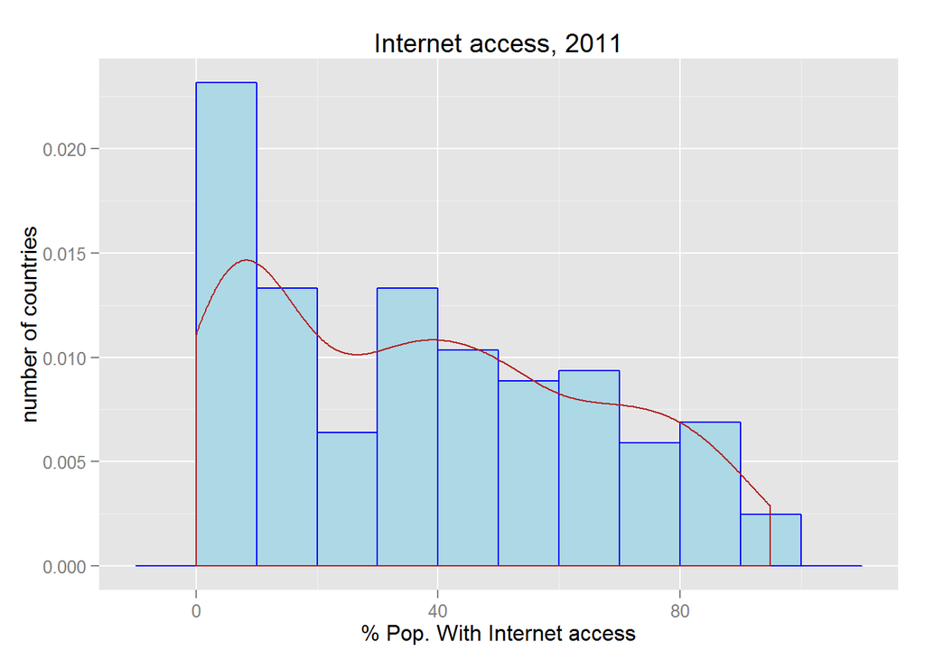

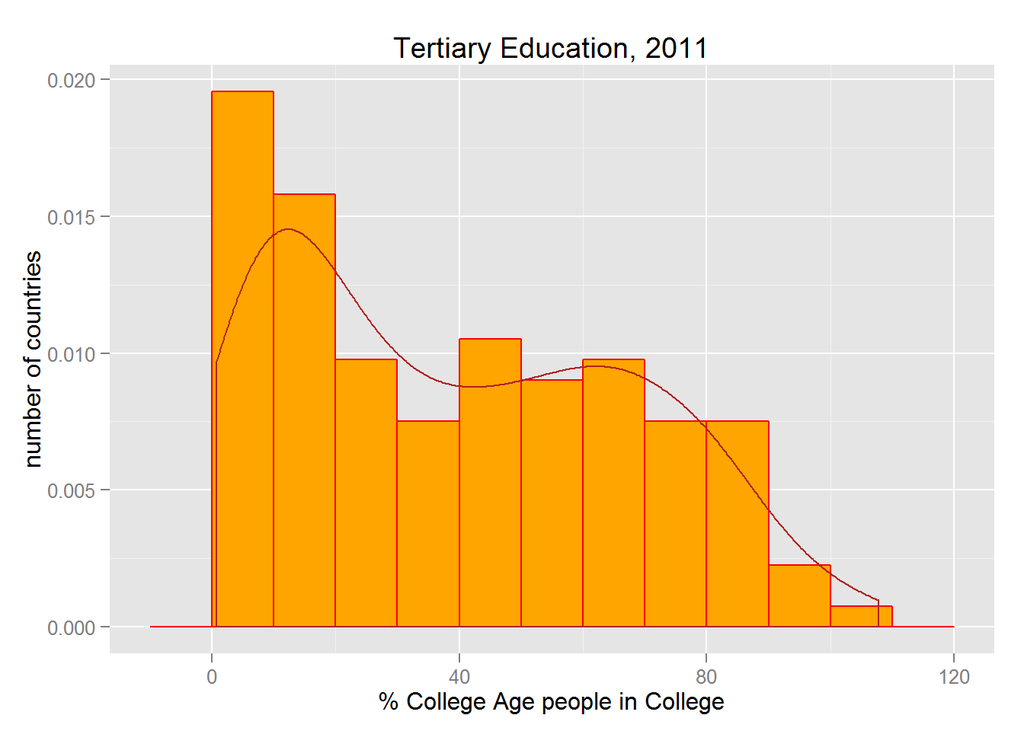

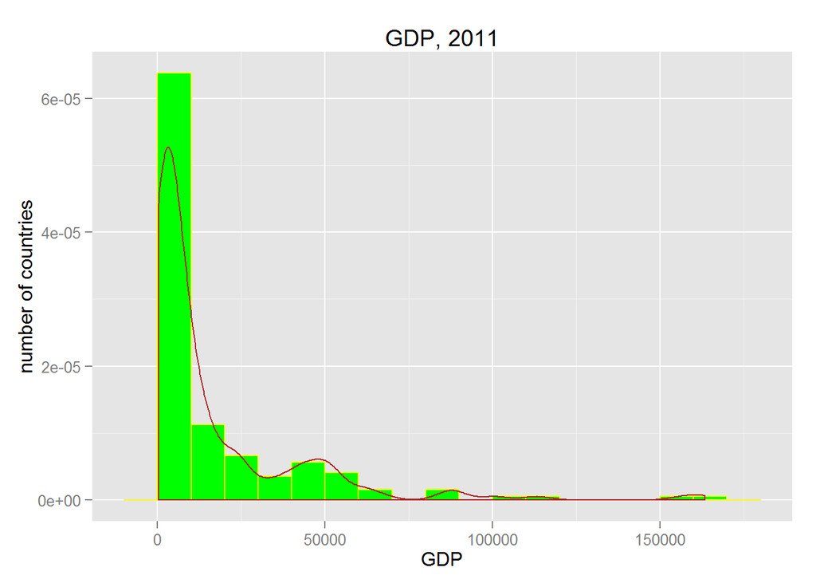

All are right-skewed, GDP heavily so. This may give result in problems with assumptions for inference down the line.